# Analyzing the NYC Subway Dataset

#### Sam Wigley Oct. 15, 2015

### Part 1. Problem Set Questions

#### PS 2.0 Initial setup and data input

```python
import csv
import pandas as pd
import numpy as np
import datetime
import pandasql
import matplotlib.pyplot as plt
%matplotlib inline

weather_data = pd.read_csv('turnstile_weather_v2.csv')
orig_weather_data = pd.read_csv('turnstile_data_master_with_weather.csv')

print "weather_data columns: "
print weather_data.columns.values
print "orig_weather_data columns: "
print orig_weather_data.columns.values
```

```
weather_data columns:
['UNIT' 'DATEn' 'TIMEn' 'ENTRIESn' 'EXITSn' 'ENTRIESn_hourly'
 'EXITSn_hourly' 'datetime' 'hour' 'day_week' 'weekday' 'station'
 'latitude' 'longitude' 'conds' 'fog' 'precipi' 'pressurei' 'rain' 'tempi'
 'wspdi' 'meanprecipi' 'meanpressurei' 'meantempi' 'meanwspdi'
 'weather_lat' 'weather_lon']
orig_weather_data columns:
['N' 'UNIT' 'DATEn' 'TIMEn' 'Hour' 'DESCn' 'ENTRIESn_hourly'
 'EXITSn_hourly' 'maxpressurei' 'maxdewpti' 'mindewpti' 'minpressurei'
 'meandewpti' 'meanpressurei' 'fog' 'rain' 'meanwindspdi' 'mintempi'
 'meantempi' 'maxtempi' 'precipi' 'thunder']
```

#### PS 2.1 Number of Rainy Days

This function should return the count of days whenit rained, indicated by rain = 1.

```python
def num_rainy_days(data):
    '''
    Selects a count of the number of rows indicate rain = 1, or a boolean rainy day indicator
    '''

    q = "SELECT count(*) from data where rain = 1"

    #Execute your SQL command against the pandas frame
    rainy_days = pandasql.sqldf(q.lower(), locals())
    return rainy_days

#Test
print 'Test Results:'
print num_rainy_days(weather_data)
```

```
Test Results:
   count(*)
0      9585
```

#### PS 2.2 Temp on Foggy and Nonfoggy Days

This function should return the maximum temperature in the tempi column for days when it was foggy, and not foggy indicated by the column named fog = 0 or 1.

```python
def max_temp_aggregate_by_fog(data):
    '''
    Returns two rows - whether it was foggy or not (0 or 1) and the max
    maxtempi for that fog value (i.e., the maximum max temperature
    for both foggy and non-foggy days).
    '''
    q= "SELECT fog,max(tempi) as maxtempi from data group by fog;"

    #Execute your SQL command against the pandas frame
    foggy_days = pandasql.sqldf(q.lower(), locals())
    return foggy_days

#Test
print 'Test Results:'
print max_temp_aggregate_by_fog(weather_data)
```

```
Test Results:
   fog  maxtempi
0    0      86.0
1    1      62.6
```

#### PS 2.3 Mean Temp on Weekends

This function should return the average mean temperature on weekend days. For the test we used the original weather data, which includes the meantempi column, containing mean temperatures.

```python
def avg_weekend_temperature(data):
    '''
    Returns the average meantempi on days that are a Saturday
    or Sunday.
    '''

    data['date'] = pd.to_datetime(data['DATEn'])

    q = """SELECT  avg(meantempi)
                    from data
                    where  cast (strftime('%w', date) as integer) == 0
                        OR cast (strftime('%w', date) as integer) == 6;"""

    #Execute your SQL command against the pandas frame
    mean_temp_weekends = pandasql.sqldf(q.lower(), locals())

    return mean_temp_weekends

orig_weather_data = pd.read_csv('turnstile_data_master_with_weather.csv')
print 'Test Results:'
print avg_weekend_temperature(orig_weather_data)
```

```
Test Results:
   avg(meantempi)
0       65.100667
```

#### PS 2.4 Mean Temp on Rainy Days

This function returns the average minimum temperature on days where it rains and the minimum temperature in the mintempi column is above 55 degrees.

```python
def avg_min_temperature(data):
    '''
    Returns the average  minimum temperature (mintempi column of the weather dataframe) on
    rainy days where the minimum temperature is greater than 55 degrees.
    '''
    #print data.head(5)
    q = """select avg(mintempi)
                from data
                where mintempi > 55
                    and rain=1;"""
    #Execute your SQL command against the pandas frame
    avg_min_temp_rainy = pandasql.sqldf(q.lower(), locals())

    return avg_min_temp_rainy

#Test
orig_weather_data = pd.read_csv('turnstile_data_master_with_weather.csv')
print 'Test Results:'
print avg_min_temperature(orig_weather_data)
```

```
Test Results:
   avg(mintempi)
0       61.23886
```

#### PS 2.5 Fixing Turnstile Data

This function reads turnstile files in their original format, and breaks lines with multiple entries per line for each turnstile into a file with one entry per line with equal column counts.

```python
def fix_turnstile_data(filenames):
    '''
    Reads input files from a set of filenames and updates each row in the text
    file so there is only one entry per row. Then write the updates to a different text
    file in the format of "updated_" + filename.
    '''
    for name in filenames:
        # your code here
        f_out = open("updated_"+name,'w')
        with open(name, 'rb') as f:
            reader = csv.reader(f, delimiter=',')
            writer = csv.writer(f_out, delimiter=',')
            for row in reader:
                sample = [row[0] , row[1] , row[2]]
                for i in range(3,len(row),5):
                    if (i + 4) <= len(row):
                        curr_row = sample + [row[i] ,row[i+1] , row[i+2]  , row[i+3], row[i+4]  ]
                        writer.writerow(curr_row)

        f_out.close

#Test

print 'Test Results:'
fix_turnstile_data(['turnstile_110507.txt','turnstile_110528.txt'])

f1=pd.read_csv('updated_turnstile_110507.txt')
f2=pd.read_csv('updated_turnstile_110507.txt')
print f1.head(5)
print f2.head(5)
```

```
Test Results:
   A002  R051  02-00-00  04-30-11  00:00:00  REGULAR  003143506  001087907
0  A002  R051  02-00-00  04-30-11  04:00:00  REGULAR    3143547    1087915
1  A002  R051  02-00-00  04-30-11  08:00:00  REGULAR    3143563    1087935
2  A002  R051  02-00-00  04-30-11  12:00:00  REGULAR    3143646    1088024
3  A002  R051  02-00-00  04-30-11  16:00:00  REGULAR    3143865    1088083
4  A002  R051  02-00-00  04-30-11  20:00:00  REGULAR    3144181    1088132
   A002  R051  02-00-00  04-30-11  00:00:00  REGULAR  003143506  001087907
0  A002  R051  02-00-00  04-30-11  04:00:00  REGULAR    3143547    1087915
1  A002  R051  02-00-00  04-30-11  08:00:00  REGULAR    3143563    1087935
2  A002  R051  02-00-00  04-30-11  12:00:00  REGULAR    3143646    1088024
3  A002  R051  02-00-00  04-30-11  16:00:00  REGULAR    3143865    1088083
4  A002  R051  02-00-00  04-30-11  20:00:00  REGULAR    3144181    1088132
```

#### PS 2.6 Combining Turnstile Data

This function reads a list of filenames and combines the rows from each file into a new file, with one header on the first line.

```python
def create_master_turnstile_file(filenames, output_file):
    '''
    Reads files from a list of input filenames, which all have the
    columns 'C/A, UNIT, SCP, DATEn, TIMEn, DESCn, ENTRIESn, EXITSn', and consolidates
    them into one file located at output_file.
    '''
    with open(output_file, 'w') as master_file:
        master_file.write('C/A,UNIT,SCP,DATEn,TIMEn,DESCn,ENTRIESn,EXITSn\n')
        for filename in filenames:
            # your code here

            with open(filename, 'rb') as f:
                reader = csv.reader(f, delimiter=',')
                writer = csv.writer(master_file, delimiter=',')
                for row in reader:
                    writer.writerow(row)

                f.close
        master_file.close
create_master_turnstile_file(['updated_turnstile_110507.txt','updated_turnstile_110528.txt'],'combined_turnstile_files.txt')

print 'Test Results:'
f1=pd.read_csv('combined_turnstile_files.txt')
f1.head(5)
```

```
Test Results:
```

|  | C/A | UNIT | SCP | DATEn | TIMEn | DESCn | ENTRIESn | EXITSn |
| --- | --- | --- | --- | --- | --- | --- | --- | --- |
| 0 | A002 | R051 | 02-00-00 | 04-30-11 | 00:00:00 | REGULAR | 3143506 | 1087907 |
| 1 | A002 | R051 | 02-00-00 | 04-30-11 | 04:00:00 | REGULAR | 3143547 | 1087915 |
| 2 | A002 | R051 | 02-00-00 | 04-30-11 | 08:00:00 | REGULAR | 3143563 | 1087935 |
| 3 | A002 | R051 | 02-00-00 | 04-30-11 | 12:00:00 | REGULAR | 3143646 | 1088024 |
| 4 | A002 | R051 | 02-00-00 | 04-30-11 | 16:00:00 | REGULAR | 3143865 | 1088083 |

#### PS 2.7 Filtering Irregular Data

This function reads a file and only regurns rows where the DESCn column is equal to the value 'REGULAR'.

```python
def filter_by_regular(filename):
    '''
    This function reads the csv file located at filename into a pandas dataframe,
    and filter the dataframe to only rows where the 'DESCn' column has the value 'REGULAR'.
    '''

    turnstile_data = pd.read_csv(filename)
    turnstile_data = turnstile_data[turnstile_data['DESCn']=='REGULAR']
    return turnstile_data

#Test
print 'Test Results:'
filter_by_regular('combined_turnstile_files.txt').head(5)
```

```
Test Results:
```

|  | C/A | UNIT | SCP | DATEn | TIMEn | DESCn | ENTRIESn | EXITSn |
| --- | --- | --- | --- | --- | --- | --- | --- | --- |
| 0 | A002 | R051 | 02-00-00 | 04-30-11 | 00:00:00 | REGULAR | 3143506 | 1087907 |
| 1 | A002 | R051 | 02-00-00 | 04-30-11 | 04:00:00 | REGULAR | 3143547 | 1087915 |
| 2 | A002 | R051 | 02-00-00 | 04-30-11 | 08:00:00 | REGULAR | 3143563 | 1087935 |
| 3 | A002 | R051 | 02-00-00 | 04-30-11 | 12:00:00 | REGULAR | 3143646 | 1088024 |
| 4 | A002 | R051 | 02-00-00 | 04-30-11 | 16:00:00 | REGULAR | 3143865 | 1088083 |

#### PS 2.8 Get Hourly Entries

This function takes a dataframe as input, and it adds a derrived column called ENTRIESn_hourly that calculates the number of entries houlry by subtracting the value ENTRIESn of the record from the previous hour from the next entry to get an hourly total.

```python
def get_hourly_entries(df):
    '''
    This function changes these cumulative entry numbers to a count of entries since the last reading
    and stores the value in a column named ENTRIESn_hourly
    (i.e., entries since the last row in the dataframe).
    '''
    #your code here
    df_prev = df['ENTRIESn'].shift(1)

    df['ENTRIESn_hourly'] = df['ENTRIESn'] - df_prev
    #df['ENTRIESn_hourly'].iloc(0).replace(1)
    #print df.head(4).fillna(1)
    return df.fillna(1)

#Test
print 'Test Results:'
data = pd.read_csv('combined_turnstile_files.txt')
get_hourly_entries(data).head(5)
```

```
Test Results:
```

|  | C/A | UNIT | SCP | DATEn | TIMEn | DESCn | ENTRIESn | EXITSn | ENTRIESn_hourly |
| --- | --- | --- | --- | --- | --- | --- | --- | --- | --- |
| 0 | A002 | R051 | 02-00-00 | 04-30-11 | 00:00:00 | REGULAR | 3143506 | 1087907 | 1 |
| 1 | A002 | R051 | 02-00-00 | 04-30-11 | 04:00:00 | REGULAR | 3143547 | 1087915 | 41 |
| 2 | A002 | R051 | 02-00-00 | 04-30-11 | 08:00:00 | REGULAR | 3143563 | 1087935 | 16 |
| 3 | A002 | R051 | 02-00-00 | 04-30-11 | 12:00:00 | REGULAR | 3143646 | 1088024 | 83 |
| 4 | A002 | R051 | 02-00-00 | 04-30-11 | 16:00:00 | REGULAR | 3143865 | 1088083 | 219 |

#### PS 2.9 Get Hourly Exits

This function calculates the number of exists since the last reading by subtracting the previous row's EXISTSn value from the same column in the current row, and adds this value under a column named EXITSn_hourly.

```python
def get_hourly_exits(df):
    '''
    This function changes the cumulative exit numbers to a count of exits since the last reading
    and stores the result in a new column named EXITSn_hourly.
    '''

    df_prev = df['EXITSn'].shift(1)
    df['EXITSn_hourly'] = df['EXITSn'] - df_prev

    return df.fillna(0)

#Test
print 'Test Results:'
data = pd.read_csv('combined_turnstile_files.txt')
print get_hourly_exits(data).head(5)
```

```
Test Results:
    C/A  UNIT       SCP     DATEn     TIMEn    DESCn  ENTRIESn   EXITSn  \
0  A002  R051  02-00-00  04-30-11  00:00:00  REGULAR   3143506  1087907
1  A002  R051  02-00-00  04-30-11  04:00:00  REGULAR   3143547  1087915
2  A002  R051  02-00-00  04-30-11  08:00:00  REGULAR   3143563  1087935
3  A002  R051  02-00-00  04-30-11  12:00:00  REGULAR   3143646  1088024
4  A002  R051  02-00-00  04-30-11  16:00:00  REGULAR   3143865  1088083

   EXITSn_hourly
0              0
1              8
2             20
3             89
4             59
```

#### PS 2.10 Time to Hour

This function converts a time format with a two digit hour into a single integer value, removing any most significant digits that are zero, to return only a single digit number if the value is less than 10.

```python
def time_to_hour(time):
    '''
    Given an input variable time that represents time in the format of:
    "00:00:00" (hour:minutes:seconds)
    returns the hour value as an integer without any leading zero.
    '''

    hour = int(time.split(':')[0])
    return hour

#Test
print 'Input Values:'
print '10:35:00'
print '22:55:00'
print '02:12:00'
print '\nTest Results:'
print time_to_hour('10:35:00')
print time_to_hour('22:55:00')
print time_to_hour('02:12:00')
```

```
Input Values:
10:35:00
22:55:00
02:12:00

Test Results:
10
22
2
```

#### PS 2.11 Reformat Subway Dates

This function should take a value in the MTA Subway date format mm-dd-yy and returns an equivilent date in the Weather Underground date format YYYY-mm-dd, so datasets from both sources can be joined and compared.

```python
def reformat_subway_dates(date):
    '''
    Takes MTA Subway date format as input and returns Weather Underground date format.
    '''

    date_formatted = datetime.datetime.strptime(date,"%m-%d-%y").strftime("%Y-%m-%d") # your code here

    return date_formatted

#Test
print 'Test Results:'
print 'Input Values:'
print '10-09-15'
print '02-28-13'
print '06-01-12'
print '\nTest Results:'
print reformat_subway_dates('10-09-15')
print reformat_subway_dates('02-28-13')
print reformat_subway_dates('06-01-12')
```

```
Test Results:
Input Values:
10-09-15
02-28-13
06-01-12

Test Results:
2015-10-09
2013-02-28
2012-06-01
```

#### PS 3.1 Exploratory Data Analysis

```
Test Results:
```

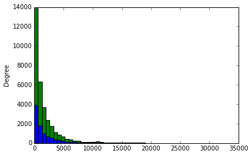

```python
def entries_histogram(turnstile_weather):
    '''
    Plots two histograms on the same axes to show hourly
    entries when raining vs. when not raining.
    '''

    plt.figure()
    # your code here to plot a historgram for hourly entries when it is raining
    turnstile_weather['ENTRIESn_hourly'][turnstile_weather['rain']==0] \
        .plot(kind='hist', stacked=True, bins=50, color='green')

    # your code here to plot a historgram for hourly entries when it is not raining
    turnstile_weather['ENTRIESn_hourly'][turnstile_weather['rain']==1] \
        .plot(kind='hist', stacked=True, bins=50, color='blue')
    return plt

#Test
print 'Test Results:'
entries_histogram(weather_data).show()
```

#### PS 3.2 Welch's T-Test?

Should the Welch's T-Test be used to compare the difference in these two sets?

> The histogram above shows that the data is not normally distributed, therefore a the Welch's t-test is not an appropriate test of the two samples.

> The Mann Whitney U-test can be used to test non-normalaly distributed sets like these.

#### PS 3.3 Mann-Whitney U-Test

```python
import scipy
import scipy.stats


def mann_whitney_plus_means(turnstile_weather):
    '''
    This function consumes the turnstile_weather dataframe containing
    our final turnstile weather data.
    dataframe.

    This function returns:
        1) the mean of entries with rain
        2) the mean of entries without rain
        3) the Mann-Whitney U-statistic and p-value comparing the number of entries
           with rain and the number of entries without rain
    '''
    with_rain = turnstile_weather['ENTRIESn_hourly'][turnstile_weather['rain']==1]
    without_rain = turnstile_weather['ENTRIESn_hourly'][turnstile_weather['rain']==0]
    with_rain_mean = np.mean(with_rain)
    without_rain_mean = np.mean(without_rain)
    U,p = scipy.stats.mannwhitneyu(with_rain, without_rain)
    return with_rain_mean, without_rain_mean, U, p # leave this line for the grader

print 'Test Results:'
print mann_whitney_plus_means(weather_data)
```

```
Test Results:
(2028.1960354720918, 1845.5394386644084, 153635120.5, 2.7410695712437496e-06)
```

#### PS 3.4 Ridership on Rainy vs. Nonrainy Days

> The Mann Whitney U-Test shows that the distributions are statistically different because of the really low value of the p-statistic in it's result of 2.74 x 10^-6 or 0.00000274. Since this is below the 95% CI p-value of 0.05 we can assume that there is a difference between subway ridership on rainy and non-rainy days.

#### PS 3.5 Linear Regression

```python
import statsmodels.api as sm


def linear_regression(features, values):
    """
    Performs linear regression given a data set with an arbitrary number of features.
    """
    features = sm.add_constant(features)
    model = sm.OLS(values,features)
    results = model.fit()
    intercept = results.params[0]
    params = results.params[1:]

    return intercept, params

def predictions(dataframe):
    '''
    The NYC turnstile data is stored in a pandas dataframe called weather_turnstile.
    Using the information stored in the dataframe.  This function predicts the ridership of
    the NYC subway using linear regression with gradient descent.
    '''

    dataframe['day_of_week'] = pd.to_datetime(dataframe['DATEn'])
    dataframe['day_of_week'] = dataframe['day_of_week'].dt.dayofweek

    features = dataframe[['rain','day_of_week','hour']]

    dummy_units = pd.get_dummies(dataframe['UNIT'], prefix='unit')
    features = features.join(dummy_units)

    # Values
    values = dataframe['ENTRIESn_hourly']

    # Perform linear regression
    intercept, params = linear_regression(features, values)

    predictions = intercept + np.dot(features, params)
   # print intercept
   # print params
    return predictions

print 'Test Results: '

weather_data = pd.read_csv('turnstile_weather_v2.csv')
print predictions(weather_data)
```

```
Test Results:
[-1495.7000757  -1002.47012574   -16.01022581 ...,   458.80218144
   952.0321314   1445.26208137]
```

#### PS 3.6 Plotting Residuals

```
Test Results:
```

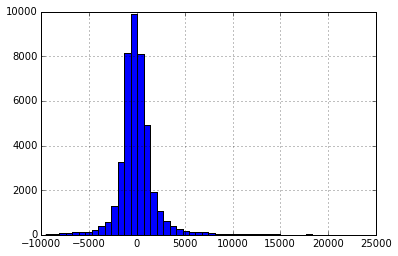

```python
import matplotlib.pyplot as plt

def plot_residuals(turnstile_weather, predictions):
    '''
    Plots a histogram of the residuals between the original hourly entry data and the predicted values.
    '''

    plt.figure()
    (turnstile_weather['ENTRIESn_hourly'] - predictions).hist(bins=50)
    return plt

print 'Test Results:'
weather_data = pd.read_csv('turnstile_weather_v2.csv')
plot_residuals(weather_data,predictions(weather_data)).show()
```

#### PS 3.7 Compute R^2

```python
import sys

def compute_r_squared(data, predictions):
    '''
    This function computes and return the coefficient of determination (R^2)
    for the input data vs. input predictions.
    '''

    n = len(data)

    rss = np.sum(np.power((data - predictions), 2))
    tss = np.sum(np.power((data - np.mean(data)), 2))

    # calculate the R Squared value
    r_squared = 1 - (rss / tss)


    return r_squared

print 'Test Results: '

weather_data = pd.read_csv('turnstile_weather_v2.csv')
print compute_r_squared(weather_data['ENTRIESn_hourly'],predictions(weather_data))
```

```
Test Results:
0.469323912949
```

#### PS 3.8 Gradient Descent

```
Test Results:
R^2: 0.460427821662
```

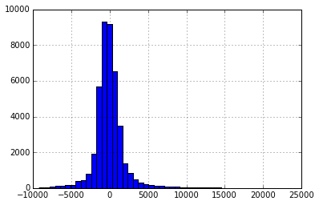

```
[-1589.72339613 -1071.80504333   -35.96833773 ...,   392.03587371
   909.95422651  1427.87257931]
```

```python
from sklearn.linear_model import SGDRegressor

"""
In this question, you need to:
1) Implement the linear_regression() procedure using gradient descent.
   You can use the SGDRegressor class from sklearn, since this class uses gradient descent.
2) Select features (in the predictions procedure) and make predictions.

"""

def normalize_features(features):
    '''
    Returns the means and standard deviations of the given features, along with a normalized feature
    matrix.
    '''
    means = np.mean(features, axis=0)
    std_devs = np.std(features, axis=0)
    normalized_features = (features - means) / std_devs
    return means, std_devs, normalized_features

def recover_params(means, std_devs, norm_intercept, norm_params):
    '''
    Recovers the weights for a linear model given parameters that were fitted using
    normalized features. Takes the means and standard deviations of the original
    features, along with the intercept and parameters computed using the normalized
    features, and returns the intercept and parameters that correspond to the original
    features.
    '''
    intercept = norm_intercept - np.sum(means * norm_params / std_devs)
    params = norm_params / std_devs
    return intercept, params

def linear_regression(features, values):
    """
    Perform linear regression given a data set with an arbitrary number of features.
    """
    clf = SGDRegressor(n_iter=50)
    clf.fit(features, values)
    intercept = clf.intercept_
    params = clf.coef_

    return intercept, params

def predictions_SGD(dataframe):
    '''
    This function predicts the ridership of the NYC subway using linear regression with gradient
    descent using certain variables from the NYC transit weather data dataframe.
    '''

    dataframe['day_of_week'] = pd.to_datetime(dataframe['DATEn'])
    dataframe['day_of_week'] = dataframe['day_of_week'].dt.dayofweek

    features = dataframe[['rain','day_of_week','hour']]
    dummy_units = pd.get_dummies(dataframe['UNIT'], prefix='unit')
    features = features.join(dummy_units)

    # Values
    values = dataframe['ENTRIESn_hourly']

    # Get numpy arrays
    features_array = features.values
    values_array = values.values

    means, std_devs, normalized_features_array = normalize_features(features_array)

    # Perform gradient descent
    norm_intercept, norm_params = linear_regression(normalized_features_array, values_array)

    intercept, params = recover_params(means, std_devs, norm_intercept, norm_params)

    predictions = intercept + np.dot(features_array, params)

    return predictions


weather_data = pd.read_csv('turnstile_weather_v2.csv')

print 'Test Results:'
print 'R^2: ' + str(compute_r_squared(weather_data['ENTRIESn_hourly'],predictions_SGD(weather_data)))
plot_residuals(weather_data,predictions_SGD(weather_data)).show()
print predictions_SGD(weather_data)
```

#### PS 4.1 Visualization 1

This visualization plots a graph showing mean ridership by hour for all rainy and non-rainy days.

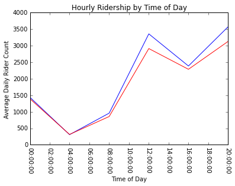

```python
import matplotlib.pyplot as plt
from datetime import datetime as dt

def plot_entries_per_hour(turnstile_weather):
    '''
    Plots a graph showing mean ridership by hour each day on rainy and non-rainy days.
    '''
    turnstile_weather['day_of_week'] = pd.to_datetime(turnstile_weather['DATEn'])
    turnstile_weather['day_of_week'] = turnstile_weather['day_of_week'].dt.dayofweek

    rainy = {0: 'non-rainy', 1:  'rainy'}

    turnstile_weather['rainy'] = turnstile_weather['rain'].apply(lambda x: rainy[x])
    turnstile_weather['time'] = turnstile_weather['TIMEn'].apply(lambda x: dt.strptime(x,'%H:%M:%S'))

    df2 = turnstile_weather.groupby(['time','rainy'])['ENTRIESn_hourly'].mean().reset_index()

    df2_rain = df2[df2['rainy']=='rainy']
    df2_no_rain = df2[df2['rainy']=='non-rainy']

    plt.plot(df2_rain['time'],df2_rain['ENTRIESn_hourly'], 'b-')

    plt.plot(df2_no_rain['time'],df2_no_rain['ENTRIESn_hourly'], 'r-')
    plt.title('Hourly Ridership by Time of Day')
    plt.xlabel('Time of Day')
    plt.ylabel('Average Daily Rider Count')
    plt.yticks(rotation=0)
    plt.xticks(rotation=-90)

    return plt


weather_data = pd.read_csv('turnstile_weather_v2.csv')
plot_entries_per_hour(weather_data).show()
```

#### PS 4.2 Visualization 2

This visualization shows the mean ridership for all stations each day of the week.

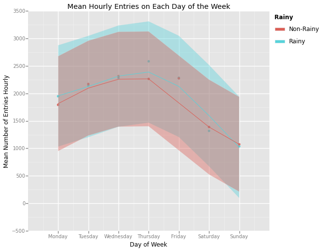

```python
from ggplot import *
import datetime

def plot_entries_per_weekday(turnstile_weather):
    '''
    Plots a graph showing the mean number of subway entries by weekday on rainy and non-rainy days
    '''

    turnstile_weather['day_of_week'] = pd.to_datetime(turnstile_weather['DATEn'])
    turnstile_weather['day_of_week'] = turnstile_weather['day_of_week'].dt.dayofweek

    rainy = {0: 'non-rainy', 1:  'rainy'}

    turnstile_weather['rainy'] = turnstile_weather['rain'].apply(lambda x: rainy[x])

    turnstile_weather = turnstile_weather.groupby(['rainy','day_of_week'])['ENTRIESn_hourly'].mean()
    turnstile_weather = turnstile_weather.reset_index()
    #print turnstile_weather
    plot = ggplot(turnstile_weather, aes(x='day_of_week', y='ENTRIESn_hourly', color='rainy',fill='rainy')) + \
        geom_point() + \
        stat_smooth() + \
        xlab('Day of Week') + \
        ylab('Mean Number of Entries Hourly') + \
          scale_x_discrete(breaks = [0,1,2,3,4,5,6],  \
                labels = ['Monday','Tuesday','Wednesday','Thursday','Friday','Saturday','Sunday']) + \
            ggtitle('Mean Hourly Entries on Each Day of the Week')

    return plot


weather_data = pd.read_csv('turnstile_weather_v2.csv')
plot_entries_per_weekday(weather_data)
```

## Part 2 Questions:

#### Section 0. References

Please include a list of references you have used for this project. Please be specific - for example, instead of including a general website such as stackoverflow.com, try to include a specific topic from Stackoverflow that you have found useful.

- http://blog.yhathq.com/posts/aggregating-and-plotting-time-series-in-python.html
- https://georgemdallas.wordpress.com/2013/10/30/principal-component-analysis-4-dummies-eigenvectors-eigenvalues-and-dimension-reduction/
- https://en.wikipedia.org/wiki/Welch%27s_t_test
- http://scikit-learn.org/stable/modules/sgd.html
- http://docs.ggplot2.org/current/scale_continuous.html
- http://docs.scipy.org/doc/scipy/reference/generated/scipy.stats.mannwhitneyu.html
- http://stats.stackexchange.com/questions/36064/calculating-r-squared-coefficient-of-determination-with-centered-vs-un-center
- http://stats.stackexchange.com/questions/110380/smoother-lines-for-ggplot2
- http://matplotlib.org/users/pyplot_tutorial.html
- http://blog.yhathq.com/posts/ggplot-for-python.html
- http://matplotlib.org/examples/index.html
- http://chrisalbon.com/python/pandas_apply_operations_to_groups.html
- https://gehrcke.de/2013/07/data-analysis-with-pandas-enjoy-the-awesome/
- http://matplotlib.org/examples/pylab_examples/date_demo_convert.html
- http://matplotlib.org/1.3.0/examples/pylab_examples/legend_demo.html
- http://stackoverflow.com/questions/332289/how-do-you-change-the-size-of-figures-drawn-with-matplotlib
- https://github.com/adam-p/markdown-here/wiki/Markdown-Cheatsheet
- http://strftime.org/

#### Section 1. Statistical Test

##### 1.1 Which statistical test did you use to analyze the NYC subway data?

> Because of the results shown in the histogram of entry counts over time, we can see that the sets are not normally distributed. In fact it's positively skewed, meaning the most of the samples occour in the lower half of the histogram.

> Becaue the Welch's T-test is not appropriate for testing non-normally distributed data, we performed the Mann Whitney U-Test, wich can compare two sets of data regardless of the distribution skew.
- Did you use a one-tail or a two-tail P value?

> For this test we are using a two-tailed P value because ridership could be either greater or less on rainy days than clear days. We don't have any determination that ridership will be greater or less on rainy days, so we're performing a two-tailed test.
- What is the null hypothesis?

> In this test we are considering the null hypothosis is that ridership on the NYC subway in terms of entries per hour is not significantly different on days where there is rainy weather, when compared with days where there is clear weather.
- What is your p-critical value?

> For a two-taled test of 95% significance we use a p-critical value of 0.05. This means if the value of the p-value returned by the Mann Whitney U-test is less than 0.05, then there is a significant differnce in ridership between the rany and non-rainy sets.

##### 1.2 Why is this statistical test applicable to the dataset? In particular, consider the assumptions that the test is making about the distribution of ridership in the two samples.

> Becaue the Welch's T-test is not appropriate for testing non-normally distributed data, we performed the Mann Whitney U-Test, wich can compare two sets of data regardless of the distribution skew.

#### Section 2. Linear Regression

##### 2.1 What approach did you use to compute the coefficients theta and produce prediction for ENTRIESn_hourly in your regression model:

> I made my first prediction using Statsmodels OLS, but also used Scikit Gradient Descent to make an additional prediction for comparison.

##### 2.3 Why did you select these features in your model? We are looking for specific reasons that lead you to believe that the selected features will contribute to the predictive power of your model. Your reasons might be based on intuition. For example, response for fog might be: “I decided to use fog because I thought that when it is very foggy outside people might decide to use the subway more often.” Your reasons might also be based on data exploration and experimentation, for example: “I used feature X because as soon as I included it in my model, it drastically improved my R2 value.”

> I computed day of week because I could see that certain days were obviously busier than others and thought there could be something going on there. Once grouping by day of week, it's apparent this is a good predictor of subway ridership, probably because the majority of the people share a similar work schedule.

##### 2.4 What are the parameters (also known as "coefficients" or "weights") of the non-dummy features in your linear regression model?

> From the linear regression function I got the following values for params:
> - rain = 117.225179
> - day_of_week = -141.600626
> - hour = 123.307487

##### 2.5 What is your model’s R2 (coefficients of determination) value?

> For my linear regression model the value of R^2 is:

> 0.469

##### 2.6 What does this R2 value mean for the goodness of fit for your regression model? Do you think this linear model to predict ridership is appropriate for this dataset, given this R2 value?

> I think it's a fairly good model that could probably be improved by using the right combination of features, or additional derrived data elements. I did find that adding additional features that weren't good indicators of ridership only worsened the results.

#### Section 3. Visualization

Please include two visualizations that show the relationships between two or more variables in the NYC subway data. Remember to add appropriate titles and axes labels to your plots. Also, please add a short description below each figure commenting on the key insights depicted in the figure.

##### 3.1 One visualization should contain two histograms: one of ENTRIESn_hourly for rainy days and one of ENTRIESn_hourly for non-rainy days. You can combine the two histograms in a single plot or you can use two separate plots. If you decide to use to two separate plots for the two histograms, please ensure that the x-axis limits for both of the plots are identical. It is much easier to compare the two in that case. For the histograms, you should have intervals representing the volume of ridership (value of ENTRIESn_hourly) on the x-axis and the frequency of occurrence on the y-axis. For example, each interval (along the x-axis), the height of the bar for this interval will represent the number of records (rows in our data) that have ENTRIESn_hourly that falls in this interval. Remember to increase the number of bins in the histogram (by having larger number of bars). The default bin width is not sufficient to capture the variability in the two samples.

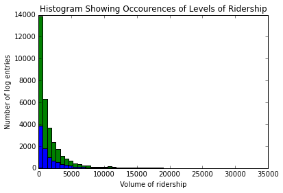

```python
def entries_histogram(turnstile_weather):
    '''
    Plots two histograms on the same axes to show hourly
    entries when raining vs. when not raining.
    '''

    turnstile_weather['ENTRIESn_hourly'][turnstile_weather['rain']==0] \
        .plot(kind='hist', stacked=True, bins=50, color='green')
    turnstile_weather['ENTRIESn_hourly'][turnstile_weather['rain']==1] \
        .plot(kind='hist', stacked=True, bins=50, color='blue')

    plt.title('Histogram Showing Occourences of Levels of Ridership')
    plt.xlabel('Volume of ridership')
    plt.ylabel('Number of log entries')

    return plt


weather_data = pd.read_csv('turnstile_weather_v2.csv')
entries_histogram(weather_data).show()
```

##### 3.2 One visualization can be more freeform. You should feel free to implement something that we discussed in class (e.g., scatter plots, line plots) or attempt to implement something more advanced if you'd like. Some suggestions are:

- Ridership by time-of-day
- Ridership by day-of-week

> This visualization shows ridership by date and time for the entire length of the dataset. It also shows entries on rainy days in a different color to visualize times when it was rainy and times when it was not.

```
<Container object of 60 artists>
```

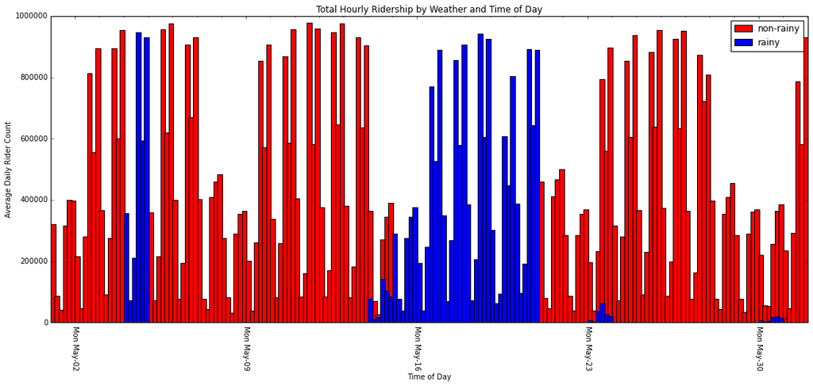

```python
from matplotlib.dates import WeekdayLocator, HourLocator, DateFormatter, DayLocator, SUNDAY, MONDAY

def plot_entries_per_hour2(turnstile_weather):
    '''
    This function plots total hourly ridership for all locations over time differentiating
    ridership on rainy days vs non-rainy days.
    '''
    rainy = {0: 'non-rainy', 1:  'rainy'}

    turnstile_weather['rainy'] = turnstile_weather['rain'].apply(lambda x: rainy[x])
    turnstile_weather['datetime'] = pd.to_datetime(turnstile_weather['datetime'])

    #turnstile_weather['date'] = pd.to_datetime(turnstile_weather['DATEn'])
    #turnstile_weather['time'] = turnstile_weather['TIMEn'].apply(lambda x: dt.strptime(x,'%H:%M:%S'))

    turnstile_weather = turnstile_weather.groupby(['datetime','rainy'])['ENTRIESn_hourly'].sum().reset_index()

    rainy_weather = turnstile_weather[turnstile_weather['rainy']=='rainy']
    nonrainy_weather = turnstile_weather[turnstile_weather['rainy']=='non-rainy']

    fig, ax = plt.subplots()
    fig.set_size_inches(18.5, 7.5, forward=True)
    plt.title('Total Hourly Ridership by Weather and Time of Day')
    plt.xlabel('Time of Day')
    plt.ylabel('Average Daily Rider Count')
    plt.yticks(rotation=0)
    plt.xticks(rotation=-90)

    ax.xaxis_date()
    ax.xaxis.set_major_formatter(DateFormatter('%a %b-%d'))
    ax.xaxis.set_minor_locator(DayLocator(interval=1))
    ax.xaxis.set_major_locator(WeekdayLocator(MONDAY))

    plot = plt.bar(nonrainy_weather['datetime'],nonrainy_weather['ENTRIESn_hourly'], \
                    label='non-rainy', color='r', width=0.2)
    plot = plt.bar(rainy_weather['datetime'],rainy_weather['ENTRIESn_hourly'], \
                   label='rainy', color='b', width=0.2)
    handles, labels = ax.get_legend_handles_labels()
    ax.legend(handles, labels)
    return plot


weather_data = pd.read_csv('turnstile_weather_v2.csv')
plot_entries_per_hour2(weather_data)
```

#### Section 4. Conclusion

Please address the following questions in detail. Your answers should be 1-2 paragraphs long.

##### 4.1 From your analysis and interpretation of the data, do more people ride the NYC subway when it is raining or when it is not raining?

> From my analysis here I would say that on days that it is raining, sigificantly more riders do ride the subway. However most days are not rainy days.

##### 4.2 What analyses lead you to this conclusion? You should use results from both your statistical tests and your linear regression to support your analysis.

> It appears that on rainy days the mean ridership is usually not much greater than non-rainy days. Referencing the chart in PS 4.2, the difference seems greatest after mid-week when ridership is at it's peak, and least on weekends when ridership tapers to it's lowest levels.

> Referencing the chart in PS 4.1, which shows mean ridership throughout the day, it also seems that mean ridership is usually close to the same between rainy and non-rainy days in the morning when people would be commuting to work, but this starts to diverge to favor more ridership in the afternoons on days when it is rainy, and less in the afternoons on days when it's not rainy. I imagine many people decide to walk home on clear days, but most people who commute on the subway in the morning, usually commute via the subway regardless of the weather conditions.

#### Section 5. Reflection

Please address the following questions in detail. Your answers should be 1-2 paragraphs long.

##### 5.1 Please discuss potential shortcomings of the methods of your analysis, including:

- Dataset,
- Analysis, such as the linear regression model or statistical test

> This dataset lacked resolution in the time of day, so it was hard to see distinct patterns throughout the day. Instead we get four-hour snapshots throughout the day. Because there are only a handfull of samples throughout the day, it makes hourly projections difficult and unclear.

> Our technique here could be a little bit more accurate with higher resolution data. The issue is we are marking some samples as a rainy day, when in actuality it only rained for part of the day. On these days we're only getting a partial day's worth of samples, and calling it a rainy day, and likewise we're getting a partial day's non-rainy samples for the same day and also calling it a non-rainy day. I think if we had higher frequency entries, we could better judge rates of ridership by hour and make better short-term and partial-day projections. If we had more data it would be best to either discard days that were partially rainy, or develop a function to return a factor for a partial day's results.

> Another issue was that there was not much more than one month's worth of data, so it makes projections based on seasonal trends impossible. In fact it's hard to say with much confidence the difference in rainy verses non-rainy ridership because there just arean't many days in our data, which are labeled rainy days.

> Linear regression and gradient descent produced similar results with similar input features. It seemed like one or the other might perform slightly better with a given set of input features. Given this dataset, I think it would be difficult to say that one algorithm consistently performed better than the other. I think it would depend on the training data and the features selected. With the current data and features it appears the Linear Regression method gets slightly better results.

##### 5.2 (Optional) Do you have any other insight about the dataset that you would like to share with us?

> I expected a higher predictive value in the latitude and longitude features since UNIT location seems to be a large component in subway ridership, but they didn't seemt to improve the result much and, in fact, they lowered the R^2 score when added. By themselves they didn't seem to be great features to use for gradient descent or linear regression. I'm still not sure why.

> Below I created what I thought could be an interesting visualization showing ridership based on latitude and longitude, but I didn't convert latitude and longitude to cartesian coordinates because I wasn't sure how to do it correctly. I thought for a spatial area as small as NYC, with data as spotty as we had, it might not matter anyway. I'm also uncertain if the surface plot was the best choice, but I'm still learning matplotlib, and it was the most interesting type I could get to work with this data.

> It created an interesting graph, which seems to show ridership is greatest at certain stations near the center of the area covered by the population and lower near the edges. I think if I had better experience with matplotlib, I could make it into a better visualization.

> I think more data would definately be helpful, both a higher level of detail time and weather-wise, and also a longer time-period of sample data. This does highlight, though just how much data is needed to get good predictive results and to find interesting combinations of features to make better predictions or assertions about the data. I think just to get started I would want hourly samples from all stations for a four-month time-period. I think this is a factor of 16 times more rows of data.

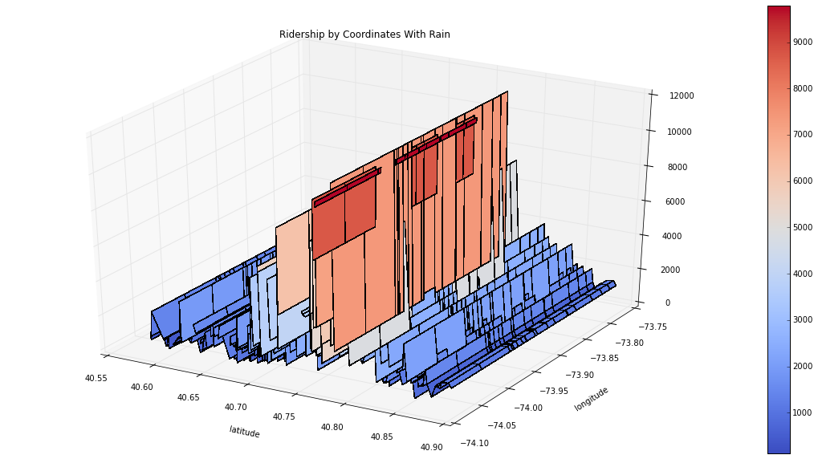

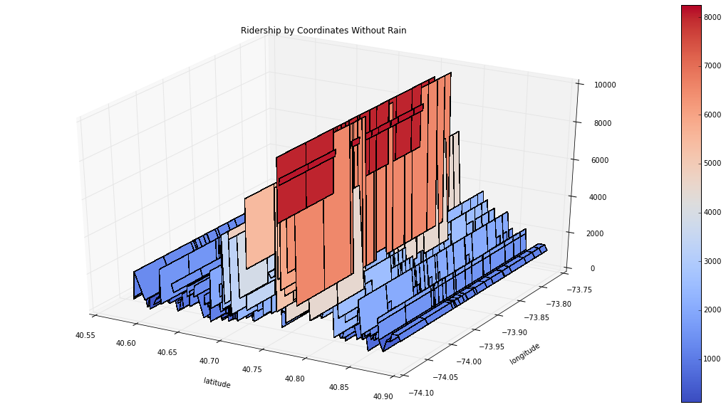

```python
from mpl_toolkits.mplot3d import Axes3D
from matplotlib import cm
#from matplotlib.colors import LightSource as ls

weather_map   = weather_data.groupby(['latitude','longitude','UNIT','rainy'])['ENTRIESn_hourly'] \
    .mean().reset_index()
rainy_days    = weather_map[weather_map['rainy']=='rainy']
nonrainy_days = weather_map[weather_map['rainy']=='non-rainy']

# weather_map.head()
fig  = plt.figure(figsize=(20,10))
fig2 = plt.figure(figsize=(20,10))

plt.xlabel('latitude')
plt.ylabel('longitude')
plt.xticks(rotation=70)
plt.yticks(rotation=-30)

ax  = fig.add_subplot(1,1,1, projection='3d')

X = rainy_days['latitude']
Y = rainy_days['longitude']
X, Y = np.meshgrid(X,Y)


Zr = rainy_days['ENTRIESn_hourly']
Znr = nonrainy_days['ENTRIESn_hourly']

ax.set_xlabel('latitude')
ax.set_ylabel('longitude')
ax.set_title('Ridership by Coordinates With Rain')
surf = ax.plot_surface(X,Y,Zr, rstride=1, cstride=1, cmap=cm.coolwarm, alpha=1, linewidth=0.1, antialiased=False)
ax.grid(True)
fig.colorbar(surf)

ax2= fig2.add_subplot(1,1,1, projection='3d')

ax2.set_xlabel('latitude')
ax2.set_ylabel('longitude')
ax2.set_title('Ridership by Coordinates Without Rain')
surf = ax2.plot_surface(X,Y,Znr, rstride=1, cstride=1, cmap=cm.coolwarm, alpha=1, linewidth=0.1, antialiased=False)
ax2.grid(True)
fig2.colorbar(surf)

plt.show()
```